# CyclisticBikeShare_Markdown

Shrey Chaudhari

2024-03-18

## Cyclistic Bike Share Data Analysis

**Introduction**  
This case study is the Capstone Project for the Google Data Analytics Professional Certificate. In this case study, I am a junior data analyst in the marketing analyst team at Cyclistic, a fictitious bike-share company in Chicago.

Cyclistic is a bike-share programme with over 5,800 bicycles and 600 docking stations. Cyclistic distinguishes itself by also providing reclining bikes, hand tricycles, and cargo bikes, making bike-share more accessible to people with disabilities and riders who cannot use a standard two-wheeled bike. The majority of riders prefer traditional bikes, with approximately 8% opting for assistive options. Cyclists are more likely to ride for pleasure, but about 30% use them to commute to work every day.

Cyclistic launched a successful bike-share programme in 2016. Since then, the programme has grown to a fleet of 5,824 geotracked bicycles that are locked into a network of 692 stations throughout Chicago. The bikes can be unlocked at any time from any station in the system and returned to any other station in the system.

The director of marketing believes that increasing the number of annual memberships is critical to the company’s future success. As a result, my team is interested in learning how casual riders and annual members use Cyclistic bikes differently. Our team will develop a new marketing strategy based on the findings to convert casual riders into annual members. However, Cyclistic executives must first approve our recommendations, which must be supported by compelling data insights and professional data visualisations.

There are 3 pricing plans: single-ride passes, full-day passes, and annual memberships. Customers who purchase single-ride or full-day passes are referred to as Casual riders. Customers who purchase annual memberships are Cyclistic members.

In order to answer the key business questions, I followed the steps of the data analysis process: ask, prepare, process, analyze, share, and act.

**Ask**  
How do Annual members and Casual riders use Cyclistic bikes differently?

The key stakeholders are:

Lily Moreno, the director of marketing and my manager.  
Cyclistic executive team.

**Prepare**  
1.The data I used is Cyclistic’s Historical Trip Data to analyze and identify trends.

3.The data is stored in CSV files. Each file contains one month data. Thus a total of 12 .csv files.

4.The data is structured data ie., Organised data.

5.The datasets have a different name because Cyclistic is a fictional company. For the purposes of this case study, the datasets are appropriate.

6.The data has been made available by Motivate International Inc.

7.As this data is collected by a real bike sharing company in Chicago, there are no issues with bias or credibility. So its Reliable, Original, Current and Cited (as in ROCCC).

As of data Integrity, its Accurate, Consistent and Trustworthy.

```r
installed.packages("tidyverse") # Data cleaning
```

```
##      Package LibPath Version Priority Depends Imports LinkingTo Suggests
##      Enhances License License_is_FOSS License_restricts_use OS_type Archs
##      MD5sum NeedsCompilation Built
```

```r
installed.packages("lubridate") # Date manipulation
```

```
##      Package LibPath Version Priority Depends Imports LinkingTo Suggests
##      Enhances License License_is_FOSS License_restricts_use OS_type Archs
##      MD5sum NeedsCompilation Built
```

```r
installed.packages("data.table") # Data exporting
```

```
##      Package LibPath Version Priority Depends Imports LinkingTo Suggests
##      Enhances License License_is_FOSS License_restricts_use OS_type Archs
##      MD5sum NeedsCompilation Built
```

```r
library(tidyverse)
library(lubridate)
library(data.table)
library(dplyr)
```

```r
data_jan23<-read.csv("Jan2023-divvy-tripdata.csv",header=TRUE)
data_feb23<-read.csv("Feb2023-divvy-tripdata.csv",header=TRUE)
data_mar23<-read.csv("Mar2023-divvy-tripdata.csv",header=TRUE)
data_apr23<-read.csv("Apr2023-divvy-tripdata.csv",header=TRUE)
data_may23<-read.csv("May2023-divvy-tripdata.csv",header=TRUE)
data_june23<-read.csv("Jun2023-divvy-tripdata.csv",header=TRUE)
data_jul23<-read.csv("Jul2023-divvy-tripdata.csv",header=TRUE)
data_aug23<-read.csv("Aug2023-divvy-tripdata.csv",header=TRUE)
data_sept23<-read.csv("Sep2023-divvy-tripdata.csv",header=TRUE)
data_oct23<-read.csv("Oct2023-divvy-tripdata.csv",header=TRUE)
data_nov23<-read.csv("Nov2023-divvy-tripdata.csv",header=TRUE)
data_dec23<-read.csv("Dec2023-divvy-tripdata.csv",header=TRUE)
```

#### Merge all files into single

```r
annual_data <-rbind(data_jan23,data_feb23,data_mar23,data_apr23,data_may23,data_june23,data_jul23,data_aug23,data_sept23,data_oct23,data_nov23,data_dec23)
```

#### Create a copy of merged file

```r
annual_data2 <- annual_data
```

#### Summary of data

```r
head(annual_data2)
```

```
##            ride_id rideable_type          started_at            ended_at
## 1 F96D5A74A3E41399 electric_bike 2023-01-21 20:05:42 2023-01-21 20:16:33
## 2 13CB7EB698CEDB88  classic_bike 2023-01-10 15:37:36 2023-01-10 15:46:05
## 3 BD88A2E670661CE5 electric_bike 2023-01-02 07:51:57 2023-01-02 08:05:11
## 4 C90792D034FED968  classic_bike 2023-01-22 10:52:58 2023-01-22 11:01:44
## 5 3397017529188E8A  classic_bike 2023-01-12 13:58:01 2023-01-12 14:13:20
## 6 58E68156DAE3E311 electric_bike 2023-01-31 07:18:03 2023-01-31 07:21:16
##              start_station_name start_station_id               end_station_name
## 1   Lincoln Ave & Fullerton Ave     TA1309000058      Hampden Ct & Diversey Ave
## 2         Kimbark Ave & 53rd St     TA1309000037        Greenwood Ave & 47th St
## 3        Western Ave & Lunt Ave           RP-005 Valli Produce - Evanston Plaza
## 4         Kimbark Ave & 53rd St     TA1309000037        Greenwood Ave & 47th St
## 5         Kimbark Ave & 53rd St     TA1309000037        Greenwood Ave & 47th St
## 6 Lakeview Ave & Fullerton Pkwy     TA1309000019      Hampden Ct & Diversey Ave
##   end_station_id start_lat start_lng  end_lat   end_lng member_casual
## 1       202480.0  41.92407 -87.64628 41.93000 -87.64000        member
## 2   TA1308000002  41.79957 -87.59475 41.80983 -87.59938        member
## 3            599  42.00857 -87.69048 42.03974 -87.69941        casual
## 4   TA1308000002  41.79957 -87.59475 41.80983 -87.59938        member
## 5   TA1308000002  41.79957 -87.59475 41.80983 -87.59938        member
## 6       202480.0  41.92607 -87.63886 41.93000 -87.64000        member
```

```r
glimpse(annual_data2)
```

```
## Rows: 5,719,877
## Columns: 13
## $ ride_id            <chr> "F96D5A74A3E41399", "13CB7EB698CEDB88", "BD88A2E670…
## $ rideable_type      <chr> "electric_bike", "classic_bike", "electric_bike", "…
## $ started_at         <chr> "2023-01-21 20:05:42", "2023-01-10 15:37:36", "2023…
## $ ended_at           <chr> "2023-01-21 20:16:33", "2023-01-10 15:46:05", "2023…
## $ start_station_name <chr> "Lincoln Ave & Fullerton Ave", "Kimbark Ave & 53rd …
## $ start_station_id   <chr> "TA1309000058", "TA1309000037", "RP-005", "TA130900…
## $ end_station_name   <chr> "Hampden Ct & Diversey Ave", "Greenwood Ave & 47th …
## $ end_station_id     <chr> "202480.0", "TA1308000002", "599", "TA1308000002", …
## $ start_lat          <dbl> 41.92407, 41.79957, 42.00857, 41.79957, 41.79957, 4…
## $ start_lng          <dbl> -87.64628, -87.59475, -87.69048, -87.59475, -87.594…
## $ end_lat            <dbl> 41.93000, 41.80983, 42.03974, 41.80983, 41.80983, 4…
## $ end_lng            <dbl> -87.64000, -87.59938, -87.69941, -87.59938, -87.599…
## $ member_casual      <chr> "member", "member", "casual", "member", "member", "…
```

```r
colnames(annual_data2)
```

```
##  [1] "ride_id"            "rideable_type"      "started_at"
##  [4] "ended_at"           "start_station_name" "start_station_id"
##  [7] "end_station_name"   "end_station_id"     "start_lat"
## [10] "start_lng"          "end_lat"            "end_lng"
## [13] "member_casual"
```

#### The merged and copied data frame was checked for duplicates and null values.

```r
duplicate_rows<- annual_data2 %>%
    filter(duplicated(annual_data2))
print(duplicate_rows)
```

```
##  [1] ride_id            rideable_type      started_at         ended_at
##  [5] start_station_name start_station_id   end_station_name   end_station_id
##  [9] start_lat          start_lng          end_lat            end_lng
## [13] member_casual
## <0 rows> (or 0-length row.names)
```

```r
annual_data2<-distinct(annual_data2)

 null_rows<-annual_data2[apply(is.na(annual_data2),1,any),]

 cleaned_annual_data<- annual_data2 %>%
     rename(member_type=member_casual,bike_type=rideable_type )
 colnames(cleaned_annual_data)
```

```
##  [1] "ride_id"            "bike_type"          "started_at"
##  [4] "ended_at"           "start_station_name" "start_station_id"
##  [7] "end_station_name"   "end_station_id"     "start_lat"
## [10] "start_lng"          "end_lat"            "end_lng"
## [13] "member_type"
```

```r
 head(cleaned_annual_data)
```

```
##            ride_id     bike_type          started_at            ended_at
## 1 F96D5A74A3E41399 electric_bike 2023-01-21 20:05:42 2023-01-21 20:16:33
## 2 13CB7EB698CEDB88  classic_bike 2023-01-10 15:37:36 2023-01-10 15:46:05
## 3 BD88A2E670661CE5 electric_bike 2023-01-02 07:51:57 2023-01-02 08:05:11
## 4 C90792D034FED968  classic_bike 2023-01-22 10:52:58 2023-01-22 11:01:44
## 5 3397017529188E8A  classic_bike 2023-01-12 13:58:01 2023-01-12 14:13:20
## 6 58E68156DAE3E311 electric_bike 2023-01-31 07:18:03 2023-01-31 07:21:16
##              start_station_name start_station_id               end_station_name
## 1   Lincoln Ave & Fullerton Ave     TA1309000058      Hampden Ct & Diversey Ave
## 2         Kimbark Ave & 53rd St     TA1309000037        Greenwood Ave & 47th St
## 3        Western Ave & Lunt Ave           RP-005 Valli Produce - Evanston Plaza
## 4         Kimbark Ave & 53rd St     TA1309000037        Greenwood Ave & 47th St
## 5         Kimbark Ave & 53rd St     TA1309000037        Greenwood Ave & 47th St
## 6 Lakeview Ave & Fullerton Pkwy     TA1309000019      Hampden Ct & Diversey Ave
##   end_station_id start_lat start_lng  end_lat   end_lng member_type
## 1       202480.0  41.92407 -87.64628 41.93000 -87.64000      member
## 2   TA1308000002  41.79957 -87.59475 41.80983 -87.59938      member
## 3            599  42.00857 -87.69048 42.03974 -87.69941      casual
## 4   TA1308000002  41.79957 -87.59475 41.80983 -87.59938      member
## 5   TA1308000002  41.79957 -87.59475 41.80983 -87.59938      member
## 6       202480.0  41.92607 -87.63886 41.93000 -87.64000      member
```

#### Ride length in seconds and minutes were created as new variable.

```r
 cleaned_annual_data$ride_length_seconds<- ymd_hms(cleaned_annual_data$ended_at)- ymd_hms(cleaned_annual_data$started_at)
 cleaned_annual_data$ride_length_minutes<-as.numeric(cleaned_annual_data$ride_length_seconds, units="mins")

 cleaned_annual_data$start_year<-format(ymd_hms(cleaned_annual_data$started_at), format="%y-%m-%d")
 cleaned_annual_data$start_month<-lubridate::month(cleaned_annual_data$start_year, label = TRUE, abbr = FALSE)

 cleaned_annual_data$end_year<-format(ymd_hms(cleaned_annual_data$ended_at), format="%y-%m-%d")
 cleaned_annual_data$end_month<-lubridate::month(cleaned_annual_data$end_year, label=TRUE, abbr=FALSE)

 cleaned_annual_data$start_day_of_week<-lubridate::wday(cleaned_annual_data$start_year, label=TRUE, abbr=FALSE)

 cleaned_annual_data<-cleaned_annual_data [,!(names(cleaned_annual_data) %in% c("ride_id","start_station_id","end_station_id","start_lat,start_lng","end_lat","end_lng"))]
```

#### Annual Rides

```r
 nrow(cleaned_annual_data)
```

```
## [1] 5719877
```

```r
 print(nrow)
```

```
## function (x)
## dim(x)[1L]
## <bytecode: 0x000001d8e88cfff8>
## <environment: namespace:base>
```

#### Count ride by members

```r
 cleaned_annual_data %>% count(member_type)
```

```
##   member_type       n
## 1      casual 2059179
## 2      member 3660698
```

#### Total rides by bike type

```r
cleaned_annual_data %>%
   group_by(bike_type)%>%
   count(bike_type)
```

```
## # A tibble: 3 × 2
## # Groups:   bike_type [3]
##   bike_type           n
##   <chr>           <int>
## 1 classic_bike  2696011
## 2 docked_bike     78287
## 3 electric_bike 2945579
```

#### Number of rides by day of week

```r
cleaned_annual_data%>%
   group_by(member_type)%>%
   count(start_day_of_week)
```

```
## # A tibble: 14 × 3
## # Groups:   member_type [2]
##    member_type start_day_of_week      n
##    <chr>       <ord>              <int>
##  1 casual      Sunday            335718
##  2 casual      Monday            234828
##  3 casual      Tuesday           246224
##  4 casual      Wednesday         249166
##  5 casual      Thursday          270612
##  6 casual      Friday            311925
##  7 casual      Saturday          410706
##  8 member      Sunday            408860
##  9 member      Monday            494576
## 10 member      Tuesday           576754
## 11 member      Wednesday         586459
## 12 member      Thursday          589590
## 13 member      Friday            531599
## 14 member      Saturday          472860
```

#### Load ggplot

```r
  installed.packages("ggplot")
```

```
##      Package LibPath Version Priority Depends Imports LinkingTo Suggests
##      Enhances License License_is_FOSS License_restricts_use OS_type Archs
##      MD5sum NeedsCompilation Built
```

```r
 library(ggplot2)
```

#### As this study contains more than 5 million observation, the plots give scientific notations. To overcome this scenario follow this.

```r
options(scipen=999)
```

#### Average trip duration by member

```r
cleaned_annual_data%>%
   group_by(member_type)%>%
   drop_na() %>%
   summarise(mean_ride_length=mean(ride_length_minutes))
```

```
## # A tibble: 2 × 2
##   member_type mean_ride_length
##   <chr>                  <dbl>
## 1 casual                  28.2
## 2 member                  12.5
```

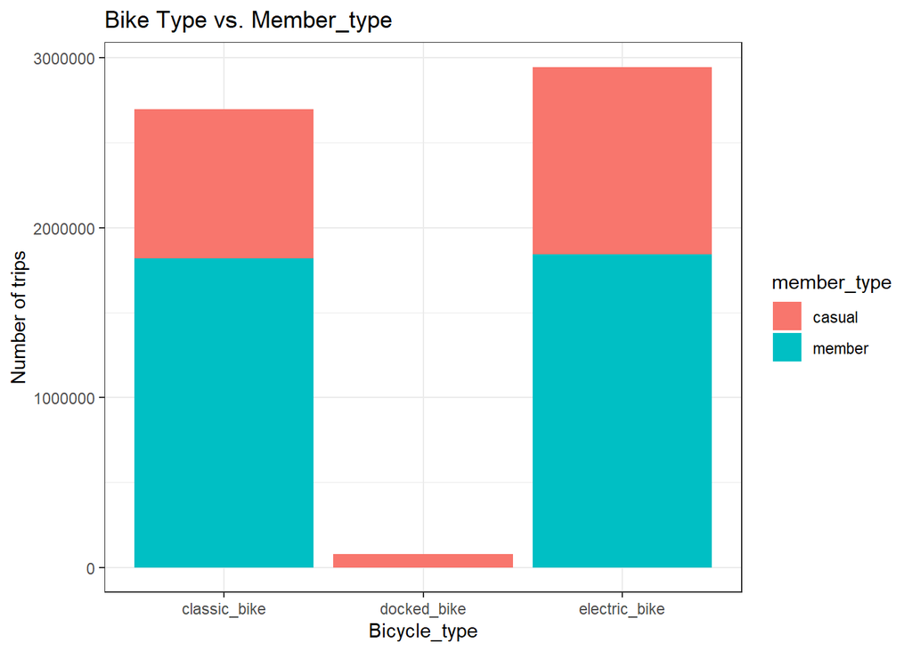

```r
cleaned_annual_data %>%
   group_by(member_type)%>%
   ggplot(aes(x=bike_type, fill=member_type, colors=member_type))+
   geom_bar()+
   theme_bw()+
   labs(title = "Bike Type vs. Member_type",x="Bicycle_type", y="Number of trips")
```

#### Plot ride by month

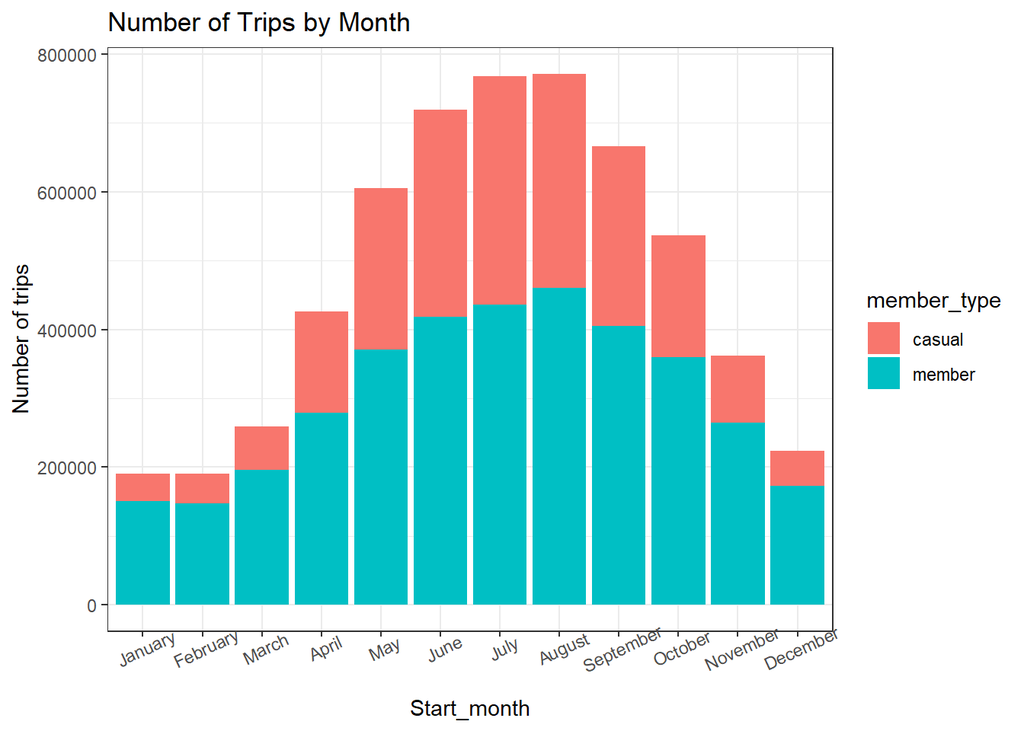

```r
 cleaned_annual_data%>%
   group_by(member_type)%>%
   ggplot(aes(x=start_month, fill=member_type, colors=member_type))+
   geom_bar()+
   theme_bw()+
   theme(axis.text.x=element_text(angle=25))+
   labs(title = "Number of Trips by Month",x="Start_month", y="Number of trips")
```

#### Plot number of rides by day

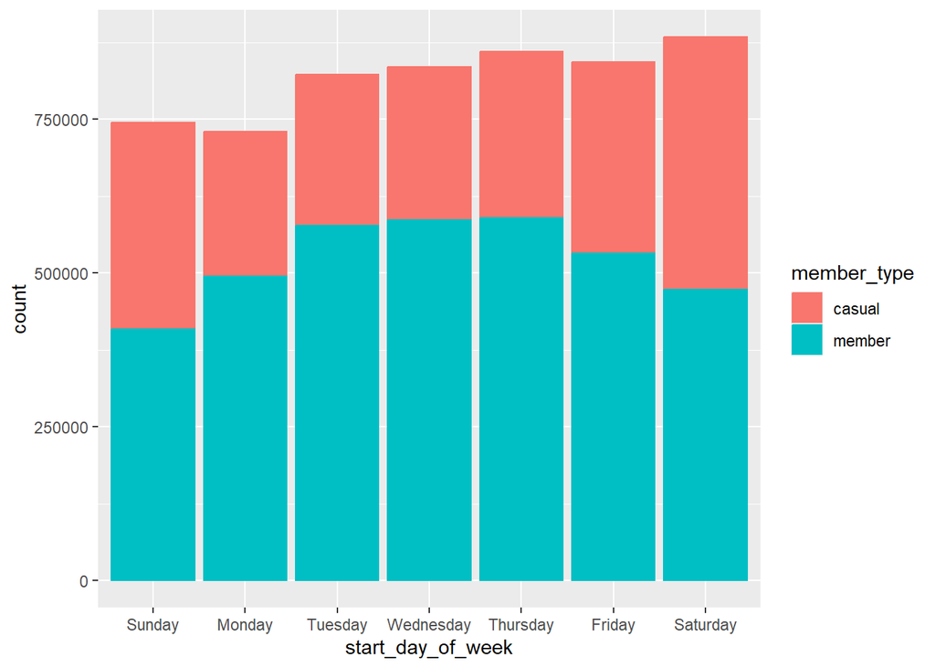

```r
cleaned_annual_data%>%
   group_by(member_type)%>%
   ggplot(aes(x=start_day_of_week, fill=member_type,color=member_type))+
   geom_bar()
```

#### Polpular start station for annual = member

```r
cleaned_annual_data%>%
   group_by(member_type,start_station_name)%>%
   summarise(number_of_ride=n())%>%
   filter(start_station_name!="", member_type=="member")%>%
   arrange(-number_of_ride)%>%
   head(5)%>%
   select(-member_type)
```

```
## # A tibble: 5 × 3
## # Groups:   member_type [1]
##   member_type start_station_name           number_of_ride
##   <chr>       <chr>                                 <int>
## 1 member      Clinton St & Washington Blvd          26216
## 2 member      Kingsbury St & Kinzie St              26172
## 3 member      Clark St & Elm St                     25001
## 4 member      Wells St & Concord Ln                 21419
## 5 member      Clinton St & Madison St               20596
```

#### Polpular start station for annual = casual

```r
cleaned_annual_data%>%
   group_by(member_type,start_station_name)%>%
   summarise(number_of_ride=n())%>%
   filter(start_station_name!="", member_type=="casual")%>%
   arrange(-number_of_ride)%>%
   head(5)%>%
   select(-member_type)
```

```
## # A tibble: 5 × 3
## # Groups:   member_type [1]
##   member_type start_station_name                 number_of_ride
##   <chr>       <chr>                                       <int>
## 1 casual      Streeter Dr & Grand Ave                     46030
## 2 casual      DuSable Lake Shore Dr & Monroe St           30487
## 3 casual      Michigan Ave & Oak St                       22664
## 4 casual      DuSable Lake Shore Dr & North Blvd          20338
## 5 casual      Millennium Park                             20228
```